# Evidencia 2 Proyecto integrador

Ignacio Reza Vera

2023-05-01

## PARTE 1 - Video

Link del video: https://youtu.be/BqFnTYRI-w0

## PARTE 2 - Código

1. Secuencias de los coronavirus de otras especies que son similares a SARS-CoV-2.

```r
virus <- c("NC_045512", # SARS-Cov2
           "MW532698", # Pangolin
           "NC_048212", # Bat
           "MZ320954", # Canine
           "NC_002306", # Feline
           "OK078898", # Porcine
           "NC_003045", # Bovine
           "NC_001451", # Avian infectious bronchitis virus
           "NC_012936", # Rat
           "NC_001846", # Murine hepatitis virus
           "NC_030292", # Ferret
           "NC_010646", # Beluga Whale
           "KF793824", # Bottlenose dolphin
           "NC_023760", # Mink
           "LN610099", # Guinea fowl
           "MN514962", # Dromedary camel
           "NC_017083", # Rabbit
           "EF424622", # Giraffe
           "ON453890", # Equine
           "LC364344", # Pigeon
           "KR822424" # European turkey
           )
virus_sequences <- read.GenBank(virus)
attr(virus_sequences, "species")
```

```
##  [1] "Severe_acute_respiratory_syndrome_coronavirus_2"
##  [2] "Pangolin_coronavirus"
##  [3] "Bat_coronavirus"
##  [4] "Canine_coronavirus"
##  [5] "Feline_infectious_peritonitis_virus"
##  [6] "Porcine_respiratory_coronavirus"
##  [7] "Bovine_coronavirus"
##  [8] "Infectious_bronchitis_virus"
##  [9] "Rat_coronavirus_Parker"
## [10] "Murine_hepatitis_virus"
## [11] "Ferret_coronavirus"
## [12] "Beluga_whale_coronavirus_SW1"
## [13] "Bottlenose_dolphin_coronavirus_HKU22"
## [14] "Mink_coronavirus_strain_WD1127"
## [15] "Guinea_fowl_coronavirus_GfCoV/FR/2011"
## [16] "Dromedary_camel_coronavirus_HKU23"
## [17] "Rabbit_coronavirus_HKU14"
## [18] "Giraffe_coronavirus_US/OH3-TC/2006"
## [19] "Equine_coronavirus"
## [20] "Pigeon_coronavirus_UAE-HKU29"
## [21] "European_turkey_coronavirus_080385d"
```

2. Calcula la longitud de las secuencias que incluyas.

```r
sapply(virus_sequences, length)
```

```
## NC_045512  MW532698 NC_048212  MZ320954 NC_002306  OK078898 NC_003045 NC_001451
##     29903     29729     28975     28807     29355     27594     31028     27608
## NC_012936 NC_001846 NC_030292 NC_010646  KF793824 NC_023760  LN610099  MN514962
##     31250     31357     28434     31686     31769     28941     27471     31021
## NC_017083  EF424622  ON453890  LC364344  KR822424
##     31100     30979     30913     26155     27739
```

3. Crea una sola gráfica donde se comparen el número de bases de ADN que componen todas las variantes del virus.

```r
write.dna(virus_sequences,  file ="virus_seqs.fasta", format = "fasta", append =
            FALSE, nbcol = 6, colsep = " ", colw = 10)
virus_seq_no_alineadas <- readDNAStringSet("virus_seqs.fasta", format = "fasta")
seq.lista <- read.fasta("virus_seqs.fasta")
seq.adn <- sapply(seq.lista, seqinr::count, wordsize = 1)
df_adn <- as.data.frame(seq.adn)
df_adn$species <- rownames(df_adn)
```

### Gráficas

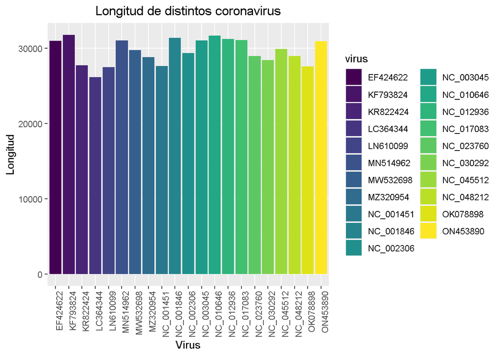

```r
seq_lengths <- sapply(virus_seq_no_alineadas, length)
seq_lengths <- data.frame(length = seq_lengths)
num_colors <- nrow(seq_lengths)
colors <- viridis(num_colors)
ggplot(data=seq_lengths, aes(x=virus, y=length, fill=virus)) +
  geom_col() +
  scale_fill_manual(values=colors) +
  xlab("Virus") + ylab("Longitud") +
  ggtitle("Longitud de distintos coronavirus") +
  theme(plot.title = element_text(hjust = 0.5)) +
  theme(axis.text.x = element_text(angle = 90, hjust = 1))
```

Esta gráfica de barras sirve para comparar el tamaño de todos los virus coronavirus que se están analizando. De esta gráfica podemos notar que todos las variantes del coronavirus estudiados son de un tamaño son bastante similares agrandes rasgos.

[figure not shown]

```r
df_adn <- df_adn %>%
  rownames_to_column(var = "secuencia") %>%
  gather(key = "species", value = "frecuencia", -secuencia)
df_prueba <- df_adn %>%
  filter(species != "species")
ggplot(df_prueba, aes(x = secuencia, y = frecuencia, col = species, fill = species)) +
  geom_density() +
  geom_bar(stat = "identity", alpha = 0.7) +
  facet_grid(~species) +
  scale_color_viridis(discrete = TRUE) +
  scale_fill_viridis(discrete = TRUE) +
  theme_minimal() +
  theme(legend.position = "bottom", strip.text.x = element_text(size = 3))
```

Aquí podemos comparar los nucleótidos que componen los virus. A diferencia de la gráfica anterior notamos que nucleótidos si difieren mucho entre sí. Esto se gracias a la alta taza de mutación con la que cuenta el SARS-Cov2 , esto qsignifica que hay varios cambios en la secuencia de nucleótidos del virus. Además, el hecho de que el sistema inmunológico de cada huesped varía así mismo el virus bucará adaptarse a este..

```r
virus_seq_no_alineadas <- OrientNucleotides(virus_seq_no_alineadas)
```

```
## ========================================================================================================================================================================================================
##
## Time difference of 0.6 secs
```

```r
virus_align_seqs <- AlignSeqs(virus_seq_no_alineadas)
```

```
## Determining distance matrix based on shared 12-mers:
## ================================================================================
##
## Time difference of 3.43 secs
##
## Clustering into groups by similarity:
## ================================================================================
##
## Time difference of 0.01 secs
##
## Aligning Sequences:
## ================================================================================
##
## Time difference of 284.89 secs
##
## Iteration 1 of 2:
##
## Determining distance matrix based on alignment:
## ================================================================================
##
## Time difference of 0.7 secs
##
## Reclustering into groups by similarity:
## ================================================================================
##
## Time difference of 5.41 secs
##
## Realigning Sequences:
## ================================================================================
##
## Time difference of 12.12 secs
##
## Alignment converged - skipping remaining iteration.
##
## Refining the alignment:
## ================================================================================
##
## Time difference of 217.61 secs
```

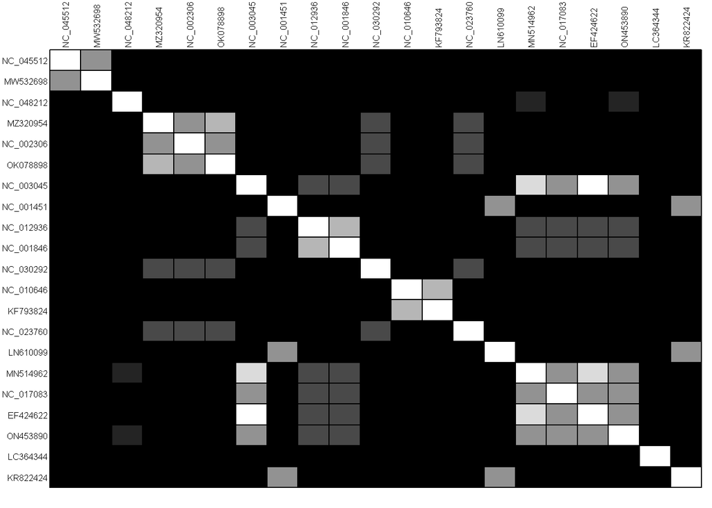

```r
writeXStringSet(virus_align_seqs, file = "virus_align_seq.fasta")
virus_aligned <- read.alignment("virus_align_seq.fasta", format = "fasta")
matriz_distancia <- dist.alignment(virus_aligned, matrix = "similarity")
temp <- as.data.frame(as.matrix(matriz_distancia))
table.paint(temp, cleg=0, clabel.row=.5, clabel.col=.5) + scale_color_viridis()
```

Esta es la gráfica que compara las secuencias después de haberlas alineado entre sí y de esta gráfica notamos que a pesar de ser el mismo virus no se parecen casi nada entre sí(ya que se observa una gran mayoría de colores oscuros); con algunas excepciones. El sars-cov-2 humano según la gráfica solo se parece medianamente (color gris claro) con el coronavirus del pangolín. Por otro lado, hay 2 coronavirus que se parecen entre sí a pesar de ser de distintas especies y estos son: el de jirafa y y el de bovino.

4. Agrega un análisis jerárquico global obtenido de las secuencias que se seleccionaron para estudiar.

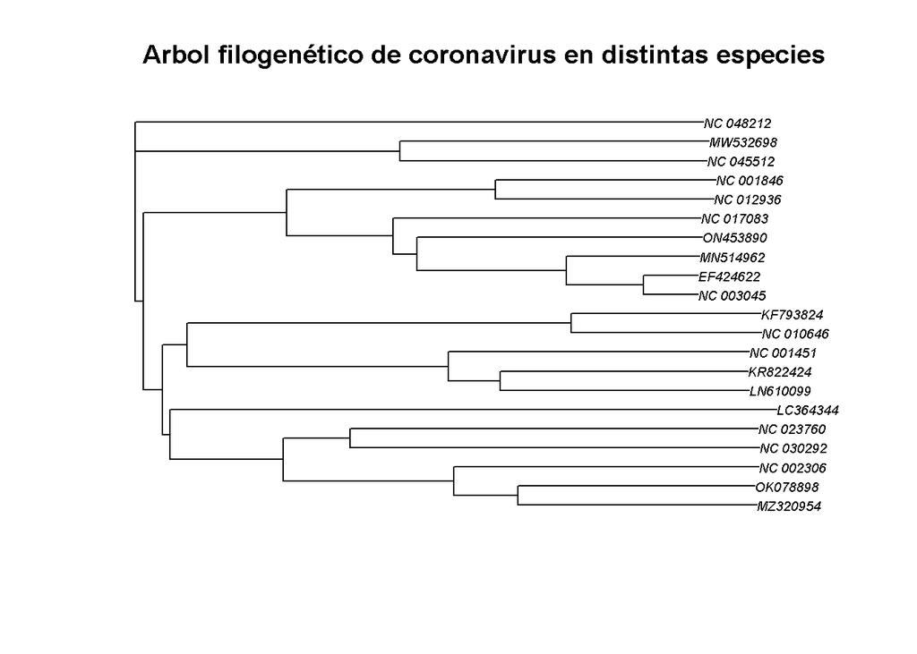

```r
virus_tree <- nj(matriz_distancia)
virus_tree <- ladderize(virus_tree)
plot(virus_tree, cex = 0.6)
title("Arbol filogenético de coronavirus en distintas especies")
```

De igual forma creamos el árbol filogenético para tener una más clara comparación de las relaciones de cercanía entree las diferentes variantes.Podemos observar que entre el sars-cov-2 humano y el coronavirus del pangolín hubo un ancestro en común. Igual podemos notar relaciones cercanas entre especies que son similares o que conviven en el mismo hábitat.

Combinacion del árbol filogenético con el alineamiento de las secuencias:

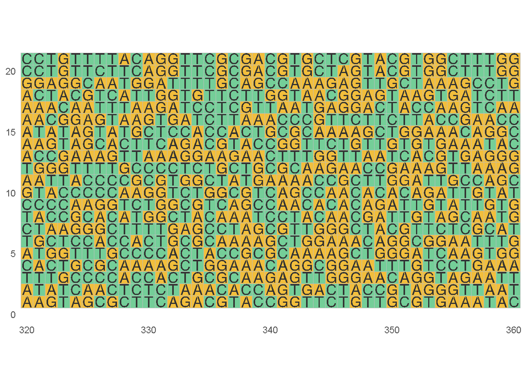

```r
ggmsa(virus_seq_no_alineadas, 320, 360, color = "Chemistry_AA")
```

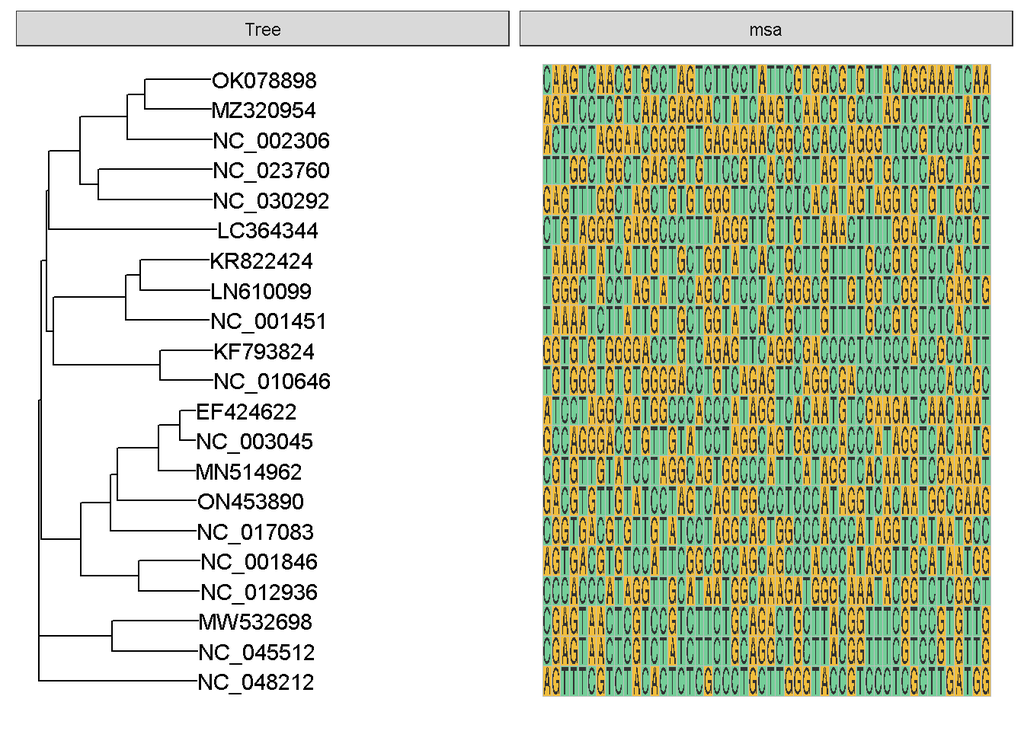

```r
plot_virus <- ggtree(virus_tree ) + geom_tiplab()

data = tidy_msa(virus_seq_no_alineadas, 164, 213)
plot_virus + geom_facet(geom = geom_msa, data = data,  panel = 'msa', color = "Chemistry_AA") +
    xlim_tree(1)
```

Aqui vemos el árbol con el alinamiento de secuencias. Y a pesar que en este caso solo se muestra un segmento en específico de la secuencia podemos notar grandes variaaciones.

5. Agrega una interpretación escrita de tus gráficas y tus conclusiones según el caso de estudio que seleccionaste. No olvides sustentar tus argumentos con las lecturas que realizaste.

### Conclusión:

Se puede llegar a la conclusión que los diferentes coronavirus en diferentes especies es el producto de mutaciones genéticas, selección natural y diferentes factores ambientales. Esto provoca que el virus tenga secuencias de nucleótidos distintas, por tanto, se adapte a diferentes ambientes.

Para este proyecto se utilizaron los genomas de pangolín y murciélago más parecidas al sars-cov-2 para observar la evolución de estos virus, de lo cual pudimos observar que en un inicio el coronavirus de murciélago tenía nula conexión con el humano, mientras que el de pangolín ya tenía una relación mayor, aunque sin llegar a ser tan similares. Por lo cual concluimos, que los virus de coronavirus tuvieron que mutar mucho para llegar a su estado actual y ser similares al sars-cov-2 humano.

En cuanto a la zoonosis o la transmisión de un virus de animales a humanos, esta ocurre a través de un proceso conocido como derrame. Durante este proceso el virus evoluciona y se adapta a un nuevo huésped lo cual permite que infecte y se propague dentro de esa población. En el caso del coronavirus este fue transmitido a los humanos a través de un huésped intermedio entre murciélagos o pangolines aunque se desconoce cual de estos dos fue el responsable a ciencia cierta.

La relación entre animales y humanos es bastante más cercana de lo que normalmente se podría pensar, esto se debe particularmente en áreas donde las personas entran en contacto con la vida silvestre o cuando consumimos productos animales en nuestra vida cotidiana. Todo esto puede aumentar en gran medida la probabilidad de transmisión zoonótica. Es por esto, que es importante estudiar este fenómeno, ya que puede prevenir y controlar futuros brotes en humano.

### Referencias

Zhu, N., Zhang, D., Wang, W., Li, X., Yang, B., Song, J., … & Niu, P. (2020). A novel coronavirus from patients with pneumonia in China, 2019. New England Journal of Medicine, 382(8), 727-733. doi: 10.1056/NEJMoa2001017

de Wit, E., van Doremalen, N., Falzarano, D., & Munster, V. J. (2016). SARS and MERS: recent insights into emerging coronaviruses. Nature Reviews Microbiology, 14(8), 523-534. doi: 10.1038/nrmicro.2016.81

Zhou, P., Yang, X. L., Wang, X. G., Hu, B., Zhang, L., Zhang, W., … & Shi, Z. L. (2020). A pneumonia outbreak associated with a new coronavirus of probable bat origin. Nature, 579(7798), 270-273. doi: 10.1038/s41586-020-2012-7

Lam, T. T., Jia, N., Zhang, Y. W., Shum, M. H., Jiang, J. F., Zhu, H. C., … & Zhang, R. (2020). Identifying SARS-CoV-2-related coronaviruses in Malayan pangolins. Nature, 583(7815), 282-285. doi: 10.1038/s41586-020-2169-0